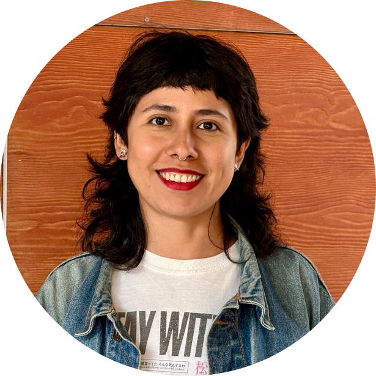

# Soledad Araya Orrego

Trabajé a tiempo completo en la **Dirección de Estudios Sociales UC** desde el 2020 a 2025, donde me especiolicé en el área cuantitativa.

Actualmente, soy docente en el Instituto de Ciencia Política UC donde imparto **Medición y análisis de datos multidimensionales** ICP5006 y **Fundamentos metodológicos** ICP5008. En la página principal puedes encontrar algunas publicaciones usadas en el curso, desde tutoriales para el uso de R a publicaciones teóricas.

Actualmente soy Campeona en el Programa de Campeones de [rOpenSci](https://ropensci.org/es/blog/2025/07/03/champions-2025) desarrollando mi primer paquete **votosCL** que contendrá la información de los resultados electorales de Chile.

Soy asistente de investigación para múltiples profesores de la **Universidad Católica de Chile** y de **Pennsylvania State University**.

## Educación

**Universidad de Chile** | Santiago, CL

- Magíster en Cine Documental, Facultad de Cine e Imagen | Abril 2021 - Diciembre 2022

**Universidad de Chile** | Santiago, CL

- Diploma de Extensión en Estudios de Género, Facultas de Filosofía y Humanidades | Abril 2018 - Diciembre 2018

**Universidad Católica de Chile** | Santiago, CL

- Ciencia Política, Instituto de Ciencia Política | Marzo 2013 - Diciembre 2017

## Experiencia profesional

**Jefa de Proyectos** - Dirección de Estudios Sociales UC **DESUC** | Agosto 2022 - Agosto 2025

- Encuesta Nacional de Juventudes ENJUV, Instituto Nacional de la Juventud | 2025.
- Encuesta Nacional de Calidad de Vida y Salud ENCAVI, Ministerio de Salud | 2023-2024
- Servicios de aplicación del Índice de Percepción Comunitaria, Corporación Nacional del Cobre CODELCO | 2020-2024
- Intergración social y territorial de Proyectos DS.19, Ministerio de Vivienda y Urbanismo y Centro de Políticas Públicas UC | 2021

**Analista de datos cuantitativos** - Dirección de Estudios Sociales UC **DESUC** | Agosto 2020 - Agosto 2022

- Encuesta Nacional de Salud, Sexualidad y Género ENSSEX, Ministerio de Salud | 2022
- Encuesta Nacional de Televisión ENTV, Consejo Nacional de Televisión | 2021

**Analista de datos** - Entrelíneas | Agosto 2019 - Abril 2020

- Estudios de mercado para Cencosud, tienda Johnson.
- Estudio cualitativo para Cencosud, tienda Paris.

## Docencia

**Pontificia Universidad Católica de Chile**

- Fundamentos metodológicos del análisis político aplicado a la práctica profesional ICP5008 | Primer semestre 2022-2025.
- Medición y análisis dimensional de datos políticos ICP5006 | Segundo semestre 2022, 2025.

## Asistencias de Investigación

**Pennsylvania State University**

- Asistente de investigación, Prof. Giancarlo Visconti (2018 - Presente) Department of Political Science of Pennsylvania State University Data building and data analysis for projects published in journals such as Political Science Research Methods, Electoral Studies, and Governance.

**Pontificia Universidad Católica de Chile**

- Asistente de investigación, Prof. Diego Díaz-Rioseco (2018 - Presente) Escuela de Gobierno FONDECYT Nº11190953, **Fiscal Origins of Democracy: How Different Sources of Nontax Income Affect Authoritarian Stability and Democratization**.
- Asistente de investigación, Prof. Carla Alberti (2020 - 2024) Instituto de Ciencia Política FONDECYT Nº11191136, **Becoming Parties: Indigenous Social Movements and Party Politics in Latin America**.
- Asistente de investigación, Prof. Carsten Schulz (2019) Instituto de Ciencia Política FONDECYT N° 11170185 **Commitment Evasion and Regional Cooperation in Latin America**.
- Asistente de investigación, Prof. Francisco Urdinez (2017 - 2019) Instituto de Ciencia Política VRI I1706/2017 FONDECYT Nº 11180081 **The International Politics of China’s Rising Role in Financing Infrastructure**.

## Capítulos de libro

- Cruz, A., Araya, S. (2020). **Data Loading**. In F. Urdinez A. Cruz (Eds.), R for Political Data Science: A Practical Guide (1st Ed., pp. 71–86). Chapman and Hall/CRC. https://doi.org/10.1201/9781003010623
- Araya, S. (2020). **Data Visualization**. In F. Urdinez A. Cruz (Eds.), R for Political Data Science: A Practical Guide (1st ed., pp. 37–66). Chapman and Hall/CRC. https://doi.org/10.1201/9781003010623